# BenchRanker copy-Copy1

### This is a library to find the best performing configuration from a set of dimensions (i.e. schemas, partition, storage) which can be specified inside the **settings.yaml** file in the resource

```python
%pip install PAPyA==0.1.0
```

### Load the configuration file and log files location for the experiment

Configurations for SP2Bench Data

```python
config_sp2bench = "settings.yaml" # config file location
logs_sp2bench = "log" # logs file location
```

Configurations for Watdiv Data

```python
config_watdiv = "settings_watdiv.yaml" # config file location
logs_watdiv = "log_watdiv" # logs file location
```

#### Configuration file

The configuration file is a yaml data-serialization language which has two main parts, the dimensions and the number of query experiments. You can add more dimensions here or change these existing dimensions to anything you need

*Example :*

```
dimensions:
    schemas: ["st", "vt", "pt", "extvt", "wpt"]
    partition: ["horizontal", "predicate", "subject"]
    storage: ["csv", "avro", "parquet", "orc"]

query: 11
```

#### Log file structure

the structure of the log files must follow the order of dimensions in the configuration file (i.e. {schemas}.{partition}.{storage}.txt) and the subfolders should be the ranking sets of the experiments (i.e. dataset sizes)

*Example :*

```
UI Module
└───log
    │
    |───100M
    |    │   st.horizontal.csv.txt
    |    │   st.horizontal.avro.txt
    |    │   ...
    │
    └───250M
        |   st.horizontal.csv.txt
        │   st.horizontal.avro.txt
        │   ...
```

### Single Dimensional Ranking

**SDRank** is a class module from PAPyA library to calculate ranking score *R* for each dimension independently that operates over a log-based structure that user specified on the configuration file.  
The value of *R* represents the performance of a particular configuration (higher value means better performing configuration). We used Ranking Function *R* below to calculate the rank scores:

$$R =\sum \limits _{r=1} ^{d} \frac{O_{dim} * (d-r)}{|Q| * (d-1)}, 0<R<=1$$

$d$ : total number of parameters (options) in a particular dimension  
$O_{dim}$ : number of occurences of the dimension placed at rank $r$ (Rank 1, Rank 2, Rank 3, ...)  
$|Q|$ : total number of queries

### PAPyA.Rank.SDRank

#### *class* Rank.**SDRank**(*config_path, log_path, ranking_sets, dimension*)

*Parameters:*  
**config_path : str**  
Specify the path to your configuration file(s). *i.e ./UIModule/settings_watdiv.yaml*</i>  
**log_path : str**  
Specify the path to your log file(s). *i.e ./UI Module/log_watdiv*</i>  
**ranking_sets : str**  
Ranking sets of user choice. *i.e dataset sizes (100M)*</i>  
**dimension : str**  
A single dimension to be ranked. *i.e schemas*</i>

```python
# this class takes single dimension and dataset sizes as parameters that user specified inside their log files
from Rank import SDRank

schemaSDRank_100M = SDRank(config_watdiv, logs_watdiv, '100M', 'schemas')
schemaSDRank_250M = SDRank(config_watdiv, logs_watdiv, '250M', 'schemas')
schemaSDRank_500M = SDRank(config_watdiv, logs_watdiv, '500M', 'schemas')
partitionSDRank_100M = SDRank(config_watdiv, logs_watdiv, '100M', 'partition')
partitionSDRank_250M = SDRank(config_watdiv, logs_watdiv, '250M', 'partition')
partitionSDRank_500M = SDRank(config_watdiv, logs_watdiv, '500M', 'partition')
storageSDRank_100M = SDRank(config_watdiv, logs_watdiv, '100M', 'storage')
storageSDRank_250M = SDRank(config_watdiv, logs_watdiv, '250M', 'storage')
storageSDRank_500M = SDRank(config_watdiv, logs_watdiv, '500M', 'storage')
```

### Rank.SDRank.calculateRank

#### SDRank.**calculateRank**(*args)

The function that automates calculating the rank scores of a single dimension using the Ranking Function above.  
Returns a table of configurations which is sorted based on the best performing configuration according to their Ranking Score along with number of occurences of the dimension being placed at the rank _r_ (1st, 2nd, 3rd, ...)  
*Parameters:*  
*args : str or list  
This method takes an arbitrary number of parameters of strings and lists.  
str -> slice the table according to string input. *i.e. "predicate" will slice the table by the **predicate** partitioning*  
list -> remove some queries out of the ranking calculations. *i.e [7,8,9] will remove query **7, 8,and 9** from the calculation*</i>

```python
schemaSDRank_100M.calculateRank().head()
```

|  | Rank 1 | Rank 2 | Rank 3 | Result |
| --- | --- | --- | --- | --- |
| vp.predicate.csv | 20.0 | 0.0 | 0.0 | 1.000 |
| vp.predicate.avro | 18.0 | 2.0 | 0.0 | 0.950 |
| pt.horizontal.parquet | 17.0 | 3.0 | 0.0 | 0.925 |
| pt.subject.avro | 16.0 | 4.0 | 0.0 | 0.900 |
| pt.horizontal.avro | 15.0 | 5.0 | 0.0 | 0.875 |

```python
schemaSDRank_250M.calculateRank().head()
```

|  | Rank 1 | Rank 2 | Rank 3 | Result |
| --- | --- | --- | --- | --- |
| vp.predicate.csv | 19.0 | 1.0 | 0.0 | 0.975 |
| vp.predicate.avro | 18.0 | 2.0 | 0.0 | 0.950 |
| pt.horizontal.avro | 17.0 | 3.0 | 0.0 | 0.925 |
| pt.horizontal.parquet | 17.0 | 3.0 | 0.0 | 0.925 |
| pt.horizontal.csv | 16.0 | 4.0 | 0.0 | 0.900 |

```python
schemaSDRank_500M.calculateRank().head()
```

|  | Rank 1 | Rank 2 | Rank 3 | Result |
| --- | --- | --- | --- | --- |
| vp.predicate.csv | 20.0 | 0.0 | 0.0 | 1.000 |
| vp.predicate.avro | 20.0 | 0.0 | 0.0 | 1.000 |
| pt.subject.avro | 17.0 | 3.0 | 0.0 | 0.925 |
| pt.subject.parquet | 16.0 | 4.0 | 0.0 | 0.900 |
| pt.horizontal.parquet | 15.0 | 5.0 | 0.0 | 0.875 |

```python
partitionSDRank_100M.calculateRank().head()
```

|  | Rank 1 | Rank 2 | Rank 3 | Result |
| --- | --- | --- | --- | --- |
| vp.predicate.orc | 17.0 | 1.0 | 2.0 | 0.875 |
| pt.subject.csv | 15.0 | 5.0 | 0.0 | 0.875 |
| pt.subject.avro | 14.0 | 6.0 | 0.0 | 0.850 |
| vp.predicate.parquet | 16.0 | 1.0 | 3.0 | 0.825 |
| pt.horizontal.orc | 13.0 | 6.0 | 1.0 | 0.800 |

```python
partitionSDRank_250M.calculateRank().head()
```

|  | Rank 1 | Rank 2 | Rank 3 | Result |
| --- | --- | --- | --- | --- |
| st.subject.avro | 17.0 | 3.0 | 0.0 | 0.925 |
| st.subject.csv | 15.0 | 5.0 | 0.0 | 0.875 |
| pt.horizontal.parquet | 14.0 | 6.0 | 0.0 | 0.850 |
| pt.subject.avro | 14.0 | 6.0 | 0.0 | 0.850 |
| st.predicate.parquet | 15.0 | 3.0 | 2.0 | 0.825 |

```python
partitionSDRank_500M.calculateRank().head()
```

|  | Rank 1 | Rank 2 | Rank 3 | Result |
| --- | --- | --- | --- | --- |
| st.predicate.csv | 19.0 | 1.0 | 0.0 | 0.975 |
| pt.subject.csv | 19.0 | 1.0 | 0.0 | 0.975 |
| vp.subject.csv | 18.0 | 2.0 | 0.0 | 0.950 |
| st.predicate.parquet | 18.0 | 2.0 | 0.0 | 0.950 |
| st.subject.avro | 16.0 | 4.0 | 0.0 | 0.900 |

```python
storageSDRank_100M.calculateRank().head()
```

|  | Rank 1 | Rank 2 | Rank 3 | Rank 4 | Result |
| --- | --- | --- | --- | --- | --- |
| st.subject.orc | 19.0 | 1.0 | 0.0 | 0.0 | 0.983333 |
| st.horizontal.orc | 16.0 | 4.0 | 0.0 | 0.0 | 0.933333 |
| vp.subject.csv | 18.0 | 0.0 | 1.0 | 1.0 | 0.916667 |
| st.predicate.orc | 13.0 | 7.0 | 0.0 | 0.0 | 0.883333 |
| vp.horizontal.csv | 15.0 | 2.0 | 2.0 | 1.0 | 0.850000 |

```python
storageSDRank_250M.calculateRank().head()
```

|  | Rank 1 | Rank 2 | Rank 3 | Rank 4 | Result |
| --- | --- | --- | --- | --- | --- |
| st.subject.orc | 19.0 | 1.0 | 0.0 | 0.0 | 0.983333 |
| st.horizontal.orc | 18.0 | 2.0 | 0.0 | 0.0 | 0.966667 |
| vp.predicate.csv | 17.0 | 2.0 | 1.0 | 0.0 | 0.933333 |
| pt.predicate.csv | 17.0 | 1.0 | 1.0 | 1.0 | 0.900000 |
| st.predicate.orc | 11.0 | 9.0 | 0.0 | 0.0 | 0.850000 |

```python
storageSDRank_500M.calculateRank().head()
```

|  | Rank 1 | Rank 2 | Rank 3 | Rank 4 | Result |
| --- | --- | --- | --- | --- | --- |
| st.subject.orc | 20.0 | 0.0 | 0.0 | 0.0 | 1.000000 |
| st.horizontal.orc | 20.0 | 0.0 | 0.0 | 0.0 | 1.000000 |
| pt.predicate.csv | 18.0 | 1.0 | 1.0 | 0.0 | 0.950000 |
| st.predicate.orc | 11.0 | 9.0 | 0.0 | 0.0 | 0.850000 |
| vp.predicate.csv | 13.0 | 5.0 | 1.0 | 1.0 | 0.833333 |

### Rank.SDRank.plotRadar

#### SDRank.**plotRadar**()

Ranking over one dimension is insufficient when it counts multiple dimensions. The presence of trade-offs reduces the accuracy of single dimension ranking functions which could be seen in the radar plot below.  
This method returns a radar chart that shows the presence of trade-offs by using the single dimension ranking criterion that reduces the accuracy of the other dimensions

```python
# This example shows a figure of the top configuration of ranking by schema is optimized towards its dimension only, ignoring the other two dimension.
from Rank import SDRank
SDRank(config_watdiv, logs_watdiv, '100M', 'schemas').plotRadar()
```

[interactive chart not shown]

```python
SDRank(config_watdiv, logs_watdiv, '100M', 'partition').plotRadar()
```

[interactive chart not shown]

```python
SDRank(config_watdiv, logs_watdiv, '100M', 'storage').plotRadar()
```

[interactive chart not shown]

### Rank.SDRank.plot

#### SDRank.**plot**(*view*)

In addition to radar plot, PAPyA also provides visualization that shows the performance of a single dimension parameters that user can choose in terms of their rank scores  
This method returns a bar chart that shows a particular dimension rankings, pivoting another dimension by user viewing projection  
*Parameters:*  
**view : str**  
This method takes a string of dimensional option that user choose to view as projection  
*Example:*  
_Schemas_ single dimensional ranking viewed from _Predicate Partitioning_ by pivoting over the _Storage_ dimension

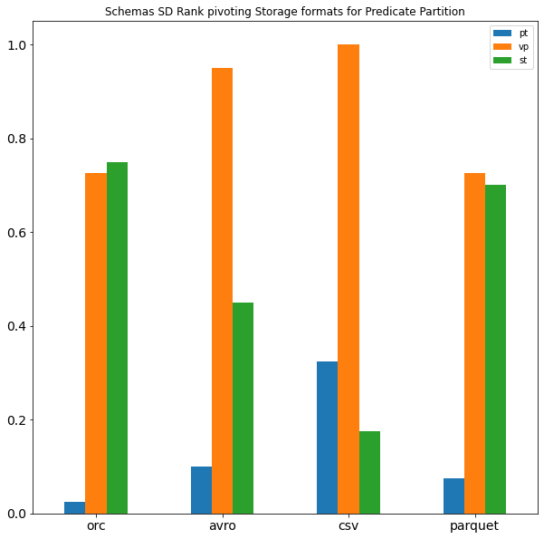

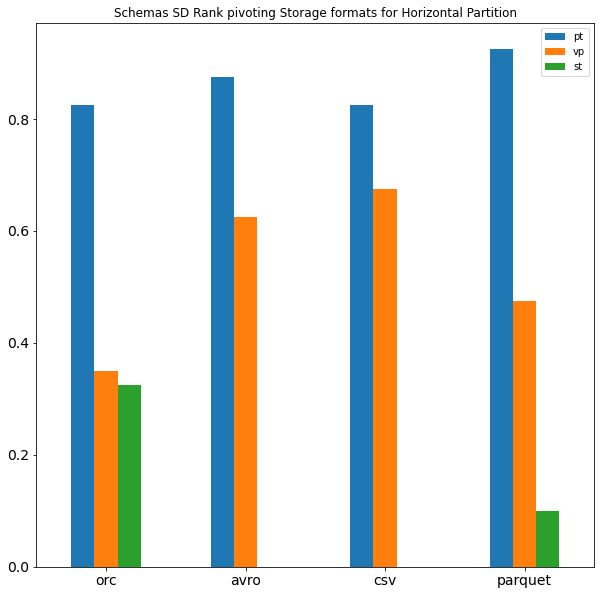

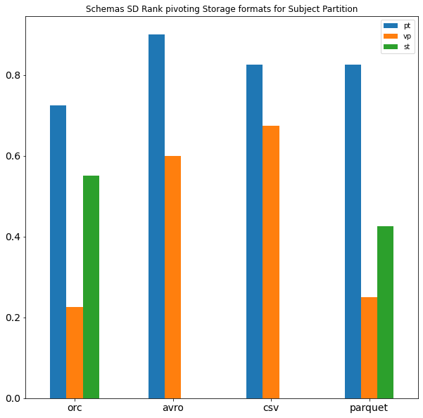

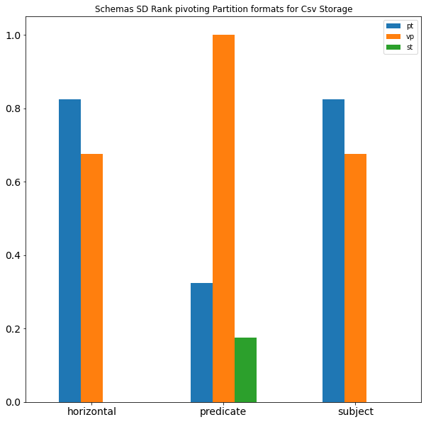

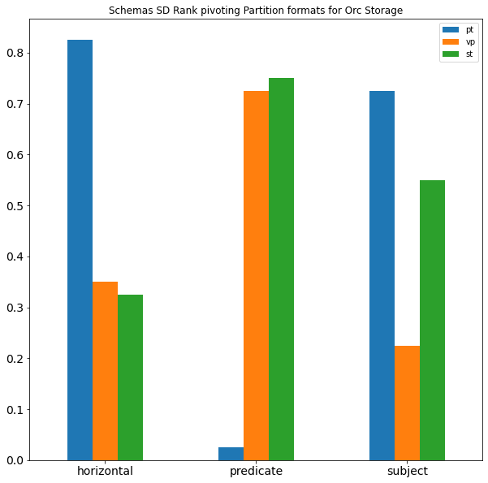

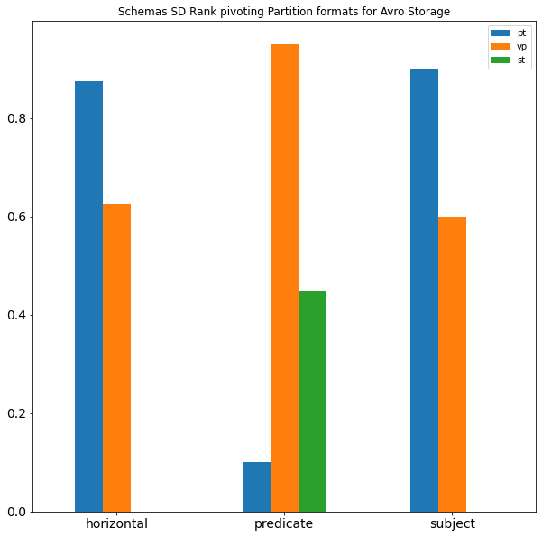

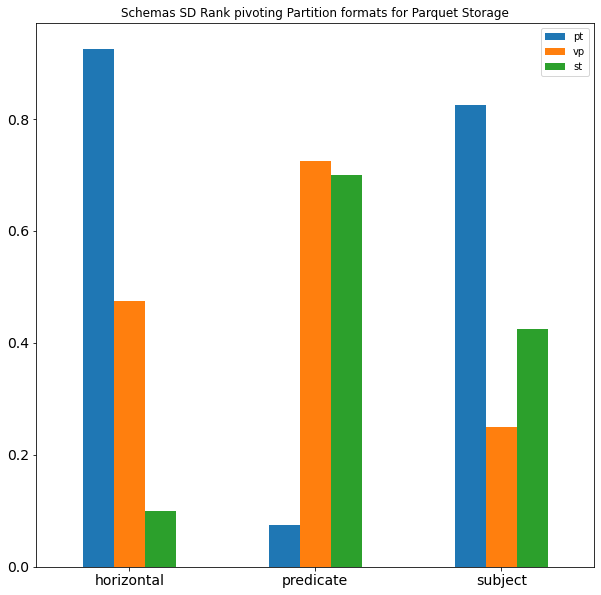

```python
from Rank import SDRank

# example of schema dimension plots
SDRank(config_watdiv, logs_watdiv, '100M', 'schemas').plot('predicate')
SDRank(config_watdiv, logs_watdiv, '100M', 'schemas').plot('horizontal')
SDRank(config_watdiv, logs_watdiv, '100M', 'schemas').plot('subject')
SDRank(config_watdiv, logs_watdiv, '100M', 'schemas').plot('csv')
SDRank(config_watdiv, logs_watdiv, '100M', 'schemas').plot('orc')
SDRank(config_watdiv, logs_watdiv, '100M', 'schemas').plot('avro')
SDRank(config_watdiv, logs_watdiv, '100M', 'schemas').plot('parquet')
```

### Rank.SDRank.plotBox

#### SDRank.**plotBox**(*q = None*)

In order to show the distributions of our query runtimes data, we need a box plot diagram to compare these data between queries in our experiment. Box plot can help provide information at a glance, giving us general information about our data  
This method returns a box plot diagram that shows both maximum and minimum runtimes of each individual queries for a particular single dimensional ranking  
*Parameters:*  
**q : list**  
This method can take a list of column names that user can specify to choose for plotting to have a more precise box plot diagram. i.e. list of ["Q1", "Q2", "Q3"] will output a  
box plot only for those queries

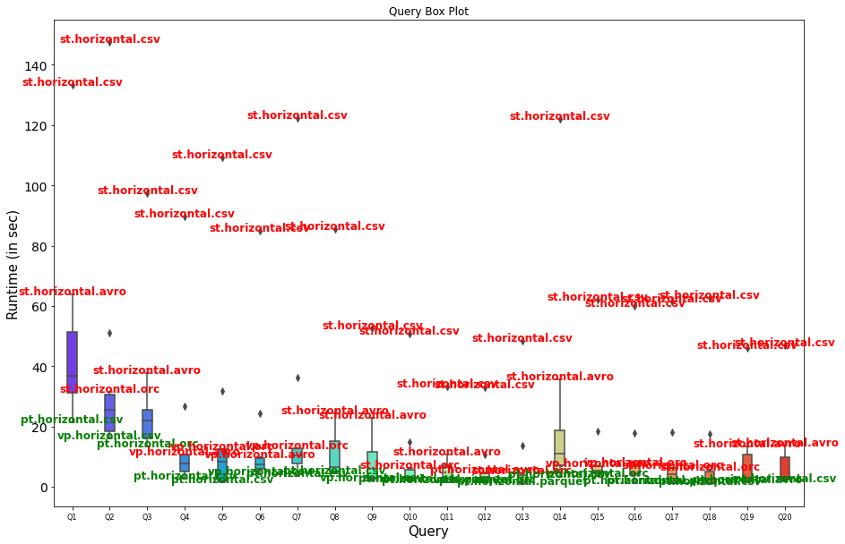

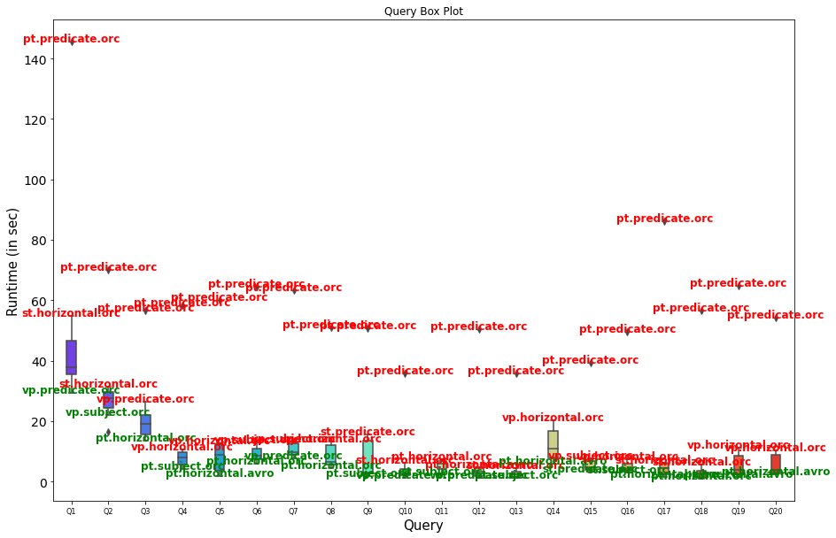

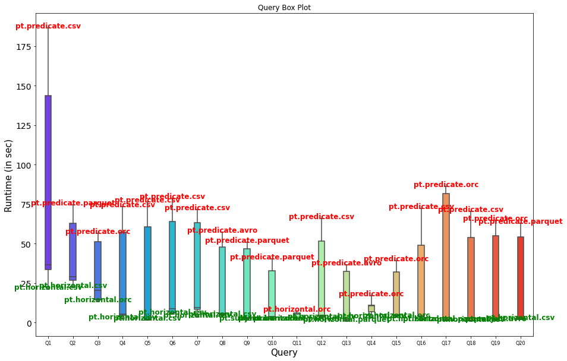

```python
from Rank import SDRank

# Box plot example of all queries of schema ranking dimension
SDRank(config_watdiv, logs_watdiv, '100M', 'schemas').plotBox()
SDRank(config_watdiv, logs_watdiv, '100M', 'partition').plotBox()
SDRank(config_watdiv, logs_watdiv, '100M', 'storage').plotBox()

# Box plot example of query 1,2,3 of schema ranking dimension
# SDRank(config_watdiv, logs_watdiv, '100M', 'schemas').plotBox(["Q1", "Q2", "Q3"])
```

### Multi Dimensional Ranking

With the presence of the trade-offs introduced in the single dimensional ranking function, we propose an optimization technique that aims to find the non-dominated solutions or the configuration combinations by optimizing all dimensions at the same time which utilize the NSGA2 Algorithm.  
In this experiment, we provide two ways to use the NSGA2 Algorithm:

- The first method is *paretoAgg* which operates on the single dimensional ranking criteria. This method aims to maximize performance of the three ranks altogether
- The second method is *paretoQ* which apply the algorithm considering the rank sets obtained by sorting each query results individually. This method aims at minimizing query runtimes of the ranked dimensions

### PAPyA.Rank.MDRank

*Parameters:*  
**config_path : str**  
Specify the path to your configuration file(s). *i.e ./UIModule/settings_watdiv.yaml*</i>  
**log_path : str**  
Specify the path to your log file(s). *i.e ./UI Module/log_watdiv*</i>  
**ranking_sets : str**  
Ranking sets of user choice. *i.e dataset sizes (100M)*</i>

```python
from Rank import MDRank

# example of MDRank class with 100M dataset size as ranking set of the experiment
multiDimensionRank_100M = MDRank(config_watdiv, logs_watdiv, '100M')
multiDimensionRank_250M = MDRank(config_watdiv, logs_watdiv, '250M')
multiDimensionRank_500M = MDRank(config_watdiv, logs_watdiv, '500M')
```

### Rank.MDRank.paretoQ

#### MDRank.**paretoQ**()

This method returns a table of configuration solutions as well as their dominated ones, according to the Non-Dominated Sorting Algorithm II (NSGA2) that was applied to minimizing query runtimes of the ranked dimensions

```python
multiDimensionRank_100M.paretoQ().head()
```

|  | Solution | Dominated |
| --- | --- | --- |
| 0 | pt.subject.csv | st.horizontal.orc |
| 1 | vp.subject.csv | st.horizontal.parquet |
| 2 | pt.horizontal.csv | st.subject.avro |
| 3 | vp.predicate.csv | st.predicate.avro |
| 4 | vp.horizontal.csv | st.horizontal.avro |

```python
multiDimensionRank_250M.paretoQ().head()
```

|  | Solution | Dominated |
| --- | --- | --- |
| 0 | pt.horizontal.parquet | st.predicate.parquet |
| 1 | pt.subject.csv | vp.predicate.parquet |
| 2 | pt.subject.avro | st.subject.parquet |
| 3 | pt.horizontal.csv | st.horizontal.orc |
| 4 | pt.horizontal.avro | st.horizontal.parquet |

```python
multiDimensionRank_500M.paretoQ().head()
```

|  | Solution | Dominated |
| --- | --- | --- |
| 0 | pt.subject.orc | vp.predicate.csv |
| 1 | pt.horizontal.orc | st.predicate.orc |
| 2 | pt.subject.parquet | vp.predicate.parquet |
| 3 | pt.horizontal.parquet | st.predicate.parquet |
| 4 | pt.subject.avro | st.horizontal.orc |

### Rank.MDRank.paretoAgg

#### MDRank.**paretoAgg**()

This method returns a table of configuration solutions as well as their dominated ones, according to the Non-Dominated Sorting Algorithm II (NSGA2) that was applied on the single dimensional ranking criteria which maximizes the performance of all ranking sets altogether

```python
multiDimensionRank_100M.paretoAgg().head()
```

|  | Solution | Dominated |
| --- | --- | --- |
| 0 | vp.predicate.avro | st.horizontal.csv |
| 1 | pt.horizontal.parquet | pt.predicate.orc |
| 2 | vp.predicate.csv | st.horizontal.avro |
| 3 | pt.horizontal.csv | pt.predicate.avro |
| 4 | st.predicate.orc | pt.predicate.parquet |

```python
multiDimensionRank_250M.paretoAgg().head()
```

|  | Solution | Dominated |
| --- | --- | --- |
| 0 | st.subject.avro | st.horizontal.csv |
| 1 | st.subject.orc | pt.predicate.parquet |
| 2 | st.predicate.orc | pt.predicate.avro |
| 3 | vp.predicate.csv | pt.predicate.orc |
| 4 | st.predicate.parquet | st.predicate.csv |

```python
multiDimensionRank_500M.paretoAgg().head()
```

|  | Solution | Dominated |
| --- | --- | --- |
| 0 | pt.predicate.csv | st.horizontal.csv |
| 1 | st.subject.orc | pt.predicate.orc |
| 2 | vp.predicate.csv | pt.predicate.parquet |
| 3 | pt.subject.avro | st.subject.csv |
| 4 | pt.subject.csv | pt.predicate.avro |

### Rank.MDRank.plot

#### MDRank.**plot**()

This method returns a plot for multi dimensional ranking solutions according to paretoAgg as shades of green projected in a three dimensional space

```
(9, 3) (27, 3)
```

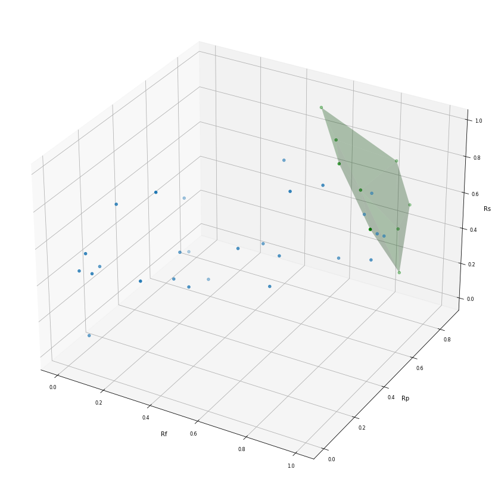

```
(6, 3) (30, 3)
```

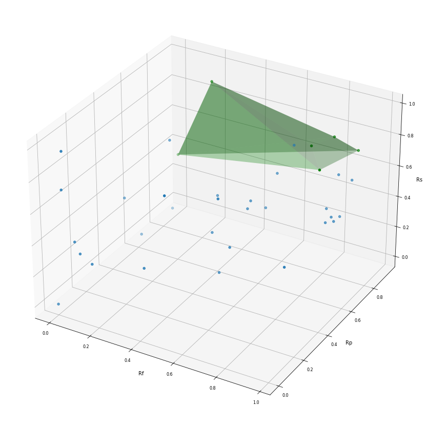

```
(11, 3) (25, 3)
```

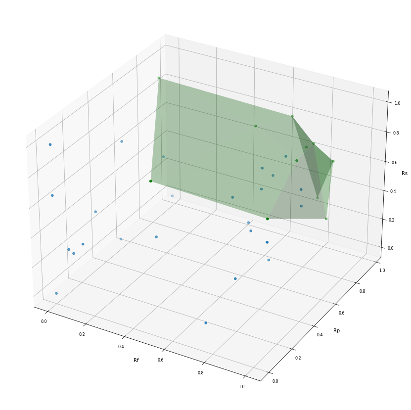

```python
multiDimensionRank_100M.plot()
multiDimensionRank_250M.plot()
multiDimensionRank_500M.plot()
```